# HW1_DATA606

alexander

9/8/2018

CHAPTER 1 INTRODUCTION TO DATA

1.8 (a) What does each row of the data matrix represent? A person with attributes (b) How many participants were included in the survey? 1691 (c) Indicate whether each variable in the study is numerical or categorical. If numerical, identify as continuous or discrete. If categorical, indicate if the variable is ordinal. Numerical Discrete: age Numerical Continous: atmWeekends, atmWeekdays Categorical:gender,maritalStatus, nationality, ethnicity, region, smoke, type Ordinal:grossIncome,highestQualification

1.10 Cheaters, scope of inference. Exercise 1.5 introduces a study where researchers studying the relationship between honesty, age, and self-control conducted an experiment on 160 children between the ages of 5 and 15. The researchers asked each child to toss a fair coin in private and to record the outcome (white or black) on a paper sheet, and said they would only reward children who report white. Half the students were explicitly told not to cheat and the others were not given any explicit instructions. Di↵erences were observed in the cheating rates in the instruction and no instruction groups, as well as some di↵erences across children’s characteristics within each group.

1. Identify the population of interest and the sample in this study. “an experiment on 160 children between the ages of 5 and 15”
2. Comment on whether or not the results of the study can be generalized to the population, and if the findings of the study can be used to establish causal relationships. It seems more like a Pareto condition than a controlled experiment. Either the whole set should be given instruction, or none at all. I don’t think that the expirment can be generalized, but may prove to be useful to understand casual relationships if removing the random elements.

1.28 Reading the paper. Below are excerpts from two articles published in the NY Times: (a) An article titled Risks: Smokers Found More Prone to Dementia states the following: “Researchers analyzed data from 23,123 health plan members who participated in a voluntary exam and health behavior survey from 1978 to 1985, when they were 50-60 years old. 23 years later, about 25% of the group had dementia, including 1,136 with Alzheimer’s disease and 416 with vascular dementia. After adjusting for other factors, the researchers concluded that pack-a- day smokers were 37% more likely than nonsmokers to develop dementia, and the risks went up with increased smoking; 44% for one to two packs a day; and twice the risk for more than two packs.” Based on this study, can we conclude that smoking causes dementia later in life? Explain your reasoning.

Maybe (probaby not.) Of all the smokers, how many died before the 23 years later cutoff? And how many non smokers died? There are many variables though, so we might be able to make an inference about smoking if there are no other criterias which increased the chances of dementia. For instance, if users who drank orange juice were 45% more likely to develop dementia, this would show there is no correlation for smoking.

2. Another article titled The School Bully Is Sleepy states the following: “The University of Michigan study, collected survey data from parents on each child’s sleep habits and asked both parents and teachers to assess behavioral concerns. About a third of the students studied were identified by parents or teachers as having problems with disruptive behavior or bullying. The researchers found that children who had behavioral issues and those who were identified as bullies were twice as likely to have shown symptoms of sleep disorders.” A friend of yours who read the article says, “The study shows that sleep disorders lead to bullying in school children.” Is this statement justified? If not, how best can you describe the conclusion that can be drawn from this study? If 1/3 of students studied had problems, and that third represents twice a likelyhood to have sleep disorders, then the conlcusion is that: One Third of students were identified as having problems by parents or teachers, and those students have a rate of sleep issues that is double that of the Two Thirds of students not identified by parents or teachers to have behavioral conerns. So the parents and teachers were able to identify kids more likely to have sleep disorders (which may be a no-brainer since it isn’t revealed whether or not the parents already knew which kids had sleep issues because the kids identified may or may not be their own children.)

1.36 Exercise and mental health. A researcher is interested in the effects of exercise on mental health and he proposes the following study: Use stratified random sampling to ensure rep- resentative proportions of 18-30, 31-40 and 41- 55 year olds from the population. Next, randomly assign half the subjects from each age group to exercise twice a week, and instruct the rest not to exercise. Conduct a mental health exam at the beginning and at the end of the study, and compare the results. (a) What type of study is this? Experiment (b) What are the treatment and control groups in this study? treatment : excercise 2x week control : ~excercise 2x a week (c) Does this study make use of blocking? If so, what is the blocking variable? Experimental units were blocked together based on age. (d) Does this study make use of blinding? No blind study - each participat was told was to do. (e) Comment on whether or not the results of the study can be used to establish a causal rela- tionship between exercise and mental health, and indicate whether or not the conclusions can be generalized to the population at large. I’d like to see more fine tuned metrics and control variables. But for the most part, this study had been made thousands of times, and can always be generalized. (f) Suppose you are given the task of determining if this proposed study should get funding. Would you have any reservations about the study proposal? Yes, it doesn’t reveal any insights based on filters to help people. Saying not smoking lessens risks of cancer is true, but how does this study help? 1.48 Stats scores. Below are the final exam scores of twenty introductory statistics students. 57, 66, 69, 71, 72, 73, 74, 77, 78, 78, 79, 79, 81, 81, 82, 83, 83, 88, 89, 94 Create a box plot of the distribution of these scores. The five number summary provided below may be useful. Min Q1 Q2 (Median) Q3 Max 57 72.5 78.5 82.5 94

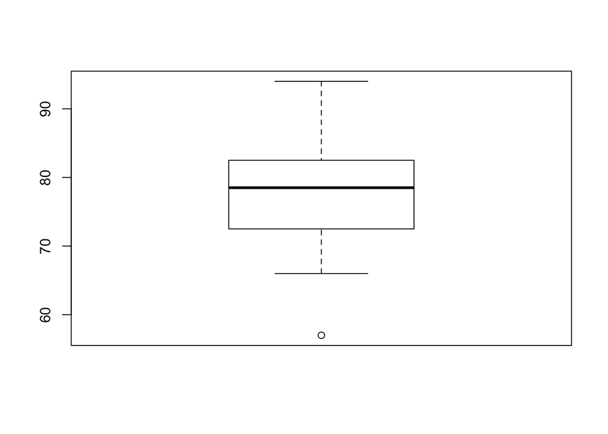

```r
exam_scores = c(57, 66, 69, 71, 72, 73, 74, 77, 78, 78, 79, 79, 81, 81, 82, 83, 83, 88, 89, 94)
boxplot(exam_scores)
```

```r
summary(exam_scores)
```

```
##    Min. 1st Qu.  Median    Mean 3rd Qu.    Max.
##   57.00   72.75   78.50   77.70   82.25   94.00
```

1.56 Distributions and appropriate statistics, Part II . For each of the following, state whether you expect the distribution to be symmetric, right skewed, or left skewed. Also specify whether the mean or median would best represent a typical observation in the data, and whether the variability of observations would be best represented using the standard deviation or IQR. Explain your reasoning. (a) Housing prices in a country where 25% of the houses cost below $350,000, 50% of the houses cost below $450,000, 75% of the houses cost below $1,000,000 and there are a meaningful number of houses that cost more than $6,000,000. Skewed right, median. (b) Housing prices in a country where 25% of the houses cost below $300,000, 50% of the houses cost below $600,000, 75% of the houses cost below $900,000 and very few houses that cost more than $1,200,000. Normal distribution, mean works. (c) Number of alcoholic drinks consumed by college students in a given week. Assume that most of these students don’t drink since they are under 21 years old, and only a few drink excessively. Right skewed and median (d) Annual salaries of the employees at a Fortune 500 company where only a few high level executives earn much higher salaries than the all other employees. Skewed right, median.

1.70 (a) Recieving treatment implies longer life. (b) Above the 75% threshold